# Introduction

**Problem Statement:** Cluster Multi Sequence Alignment (MSA) sequences for 400 Covid-19 samples.  
Additional useful information:

- The data is provided in a fasta files which is a plain ASCII text file
- The data for each sample in the fasta consists of two lines; a header line with the sequence name followed by a line that contains a modified MSA sequence
- Each MSA sequence is the same length
- The MSA sequences have been modified for simplicity
- You can treat each MSA sequence as a series of quasi-independent individual measurements
- A “.” in the MSA indicates that no change is detected in that location between all the sequences
- Each location in the sequence can be either a A,T,G,C,N, and -
- `A,T,G,C` are unique detectable result at each location in the sample
- A “N” indicates it could not be determined if it was a A,T,G,C at that location in that sample
- A “-“ indicates that nothing was detected at that location in that sample

# Report

## Project Description

In this project I did the clustering of the given Multi Sequence Alignment (MSA) of 400 covid samples. For the clustering, I used `KMeans` clustering with `kmeans++` initialization to minimize the risk of choosing poor initial points for the modelling. Kmeans is sensitive to the initially chosen centroids and `kmeans++` gives better initial centroids.

Kmeans is distance based algorithm where we can specify the number of clusters and it will tell us which data point belongs to which cluster. We can choose number of cluster based on elbow method or silhouette scores. There are also multitude of other clustering algorithms to choose from such as another distance based `k-mediods` or other density based algorithms such as `DBSCAN` and `OPTICS`. Here, I used distance based algorithm k-means with 5 clusters and used euclidean distances as the distance metric.

About the distance metric used, we could also use `absolute` or `cosine` distances here, but I used euclidean distance for simplicity. We should also note that, for normalized data, euclidean and cosine distances give the same value and it does not matter much in those situations.

The k-means algorithm comes with it's own problem. We need to choose best number of clusters. To choose the best number of clusters, I used the elbow method. First I found different within cluster sum of squared values (WCSS) for given number of clusters used and plotted number of clusters versus WCSS. Wherever we see sharp turn (elbow like shape) we choose that number as the best number of cluster.

Apart from WCSS, we can also use silhouette score to choose the best number of clusters. The Silhouette score for a data point is given by `s=(b-a)/max(a,b)` where `a` is mean distance from that point to all the points in given cluster, and `b` is to that of nearest other cluster. For a single cluster, the Silhouette score is the mean of silhouette scores of all the points belonging to it.

## Methodology

Here, we have 400 covid samples MSA and each sample has 34k characters. A single DNA has a double helix structure with four nitrogen bases Adenine(A), Thymine (T), Cytosine(C), and Guanine(G).

Also, `N` means there is one of four proteins on the place but no any protein is detected with full accuray. `.` means character is same across all samples and `-` means protein was not detected at that place.

First of all, since the data is text data, we need to convert it to numeric data somehow. We can use `k-mers` with Bag of Words (`CountVectorizer`) but that will give very large dimension array and clustering techniques may suffer from curse of dimensionality. So, I used simple ASCII Encoding of the characters. For example, the character `.` has the ASCII integer encoding of `46` and later I will normalize these numbers and do the PCA.

Again, to see how well our clustering algorithm did, I used 2-dimensional plot with cluster labels predicted from the k-means.

[figure not shown]

## Results

The number of data points assigned to each cluster index is given below:

| Cluster | Count |
| --- | --- |
| 3 | 171 |
| 0 | 161 |
| 2 | 51 |
| 4 | 9 |
| 1 | 8 |

Here, I have also included the visualization of clusters for 2 dimensional data obtained by normalized PCA data is given below:

[figure not shown]

# Load the modules

```python
import time
time_start_notebook = time.time()

import numpy as np
import pandas as pd
import pathlib
from pathlib import Path
import copy

# visualization
import matplotlib.pyplot as plt
import seaborn as sns
sns.set()
import plotly_express as px

# modelling
from sklearn.feature_extraction.text import CountVectorizer
from sklearn.preprocessing import StandardScaler
from sklearn.cluster import KMeans
from sklearn.metrics import silhouette_score
from sklearn.decomposition import PCA

import scikitplot.metrics as skpmetrics
from yellowbrick.cluster import SilhouetteVisualizer

# biopython
from Bio import SeqIO
from Bio.Cluster import kcluster,pca

# settings
SEED = 100
pd.set_option('max_columns',100)

%matplotlib inline
%load_ext watermark
%watermark -iv
```

```
numpy         : 1.19.5
pandas        : 1.2.4
Bio           : 1.79
matplotlib    : 3.3.4
autopep8      : 1.5.7
plotly_express: 0.4.1
json          : 2.0.9
scikitplot    : 0.3.7
seaborn       : 0.11.1
```

```python
# my local library
import sys
sys.path.append("/Users/poudel/Dropbox/a00_Bhishan_Modules/")
sys.path.append("/Users/poudel/Dropbox/a00_Bhishan_Modules/bhishan")
from bhishan import bp
```

# Look at the data file

```python
!ls *.fasta
```

```
Modified_Sequences.fasta
```

```python
!head -n 1 Modified_Sequences.fasta
```

```
>sequence00000
```

```python
!head -n 2 Modified_Sequences.fasta | tail -n 1 | wc -c
```

```
   34045
```

```python
!head -n 2 Modified_Sequences.fasta | head -c 1000
```

```
>sequence00000
...........................................................------------------------------------------------------AGATCTGTTCTCTAAACGAAC..........TT.TAA.....AATC..TGTGTGGCTGTCACTCGGCTGCATGCTTAGTGCACTCACGCAGTA........TAATTAATAACTAATTACTGTCGTTGACAGGACACGAGTAACTCGTCTATCTTCTGCAGGCTGCTTACGG.T.TTCGTCCG.TTTT…
```

```python
!head -n 2 Modified_Sequences.fasta | cut -c 100-200
```

```
--------------AGATCTGTTCTCTAAACGAAC..........TT.TAA.....AATC..TGTGTGGCTGTCACTCGGCTGCATGCTTAGTGCACTCAC
```

```python
!cat Modified_Sequences.fasta |wc -l
```

```
     800
```

```python
!sed -n '799p' < Modified_Sequences.fasta
```

```
>sequence00399
```

```python
# we have files 00_000 to 00_399 (total 400 covid samples)
```

```python
!du -sh Modified_Sequences.fasta
```

```
 13M	Modified_Sequences.fasta
```

```python
sequences = []
for i, seq_record in enumerate(SeqIO.parse("Modified_Sequences.fasta", "fasta")):
    sequences.append(str(seq_record.seq))
#     print(seq_record.id)
#     print(repr(seq_record.seq))
#     print(len(seq_record))
#     print()

#     if i == 3:
#         break
```

```python
seq = sequences[0]
seq[100:200]
```

```
'-------------AGATCTGTTCTCTAAACGAAC..........TT.TAA.....AATC..TGTGTGGCTGTCACTCGGCTGCATGCTTAGTGCACTCAC'
```

# Modelling

```python
from Bio.Cluster import pca
from Bio.Cluster import kcluster

from sklearn.preprocessing import StandardScaler
from sklearn.cluster import KMeans
from sklearn.metrics import silhouette_score

import scikitplot.metrics as skpmetrics
```

## Convert Sequences to Numerical Data

### k-mer and bag words embedding

```python
from sklearn.feature_extraction.text import CountVectorizer
```

```python
def get_kmers(seq, size):
    return [seq[x:x+size].upper() for x in range(len(seq) - size + 1)]
```

```python
seq = 'AGATCTGTTCTCTAAACGAAC'
words = get_kmers(seq, size=6)
joined_sentence = ' '.join(words)
joined_sentence
```

```
'AGATCT GATCTG ATCTGT TCTGTT CTGTTC TGTTCT GTTCTC TTCTCT TCTCTA CTCTAA TCTAAA CTAAAC TAAACG AAACGA AACGAA ACGAAC'
```

```python
seq = '-------------AGATCTGTTCTCTAAACGAAC..........TT.TAA'
words = get_kmers(seq, size=6)
joined_sentence = ' '.join(words)
joined_sentence
```

```
'------ ------ ------ ------ ------ ------ ------ ------ -----A ----AG ---AGA --AGAT -AGATC AGATCT GATCTG ATCTGT TCTGTT CTGTTC TGTTCT GTTCTC TTCTCT TCTCTA CTCTAA TCTAAA CTAAAC TAAACG AAACGA AACGAA ACGAAC CGAAC. GAAC.. AAC... AC.... C..... ...... ...... ...... ...... ...... .....T ....TT ...TT. ..TT.…
```

```python
seq = sequences[0]
words = get_kmers(seq, size=6)
joined_sentence = ' '.join(words)
len(seq), len(joined_sentence), joined_sentence[:10]
```

```
(34044, 238272, '...... ...')
```

```python
seq0 = sequences[0]
seq1 = sequences[1]
sentence1 = ' '.join(get_kmers(seq0, size=6))
sentence2 = ' '.join(get_kmers(seq1, size=6))
```

```python
cv = CountVectorizer()
XX = cv.fit_transform([sentence1, sentence2]).toarray()

XX.shape
```

```
(2, 4152)
```

```python
cv = CountVectorizer(ngram_range=(4,4))
XX = cv.fit_transform([sentence1, sentence2]).toarray()

XX.shape
```

```
(2, 17093)
```

```python
# This creates very long sequence and also we need to further treat no proteins (n).
# So, I have used simple numeric encoding
```

### Integer ASCII Encoding (I used this)

```python
# get numpy array
X = np.asarray([np.frombuffer(s.encode('utf-8'), dtype=np.uint8)
                     for s in sequences])

print(len(sequences), len(sequences[0]), X.shape)
X[0][0]
```

```
400 34044 (400, 34044)
```

```
46
```

```python
ord('.') # integer ascii value.
```

```
46
```

## Normalize the data

```python
from sklearn.preprocessing import StandardScaler, MinMaxScaler
```

```python
scaler = MinMaxScaler()
X_std = scaler.fit_transform(X)
```

## Clustering on full dimension 400*34k

```python
clusterid, error, nfound = kcluster(X,nclusters=2)
print(clusterid)
```

```
[0 0 0 1 0 1 1 0 0 1 0 0 1 0 1 0 1 1 1 1 1 1 0 0 0 0 1 1 0 0 1 0 1 1 0 1 0
 1 0 1 0 0 0 0 0 1 0 0 0 0 1 0 1 0 0 1 0 1 1 1 1 1 1 0 1 0 0 0 1 0 0 1 0 0
 1 0 0 0 0 1 0 0 1 1 0 0 0 1 1 1 0 0 1 1 1 1 0 1 1 1 0 0 0 0 1 1 0 0 0 0 0
 0 1 1 0 0 0 0 0 0 0 0 0 0 0 1 1 0 0 1 0 0 1 1 0 0 1 0 1 0 1 1 0 0 1 1 0 0
 0 1 1 0 1 0 1 1 1 1 0 0 1 0 1 0 1 0 0 1 1 0 1 0 1 0 0 1 0 1 0 0 0 0 1 1 0
 1 1 0 1 1 1 0 0 0 0 1 0 0 0 0 0 0 1 0 1 1 0 0 0 1 0 0 1 0 0 1 1 1 1 0 0 0
 1 1 0 1 1 1 0 1 1 0 0 1 0 0 1 1 0 0 0 1 0 0 0 1 1 1 0 1 0 0 1 0 1 1 0 1 0
 0 0 0 1 1 1 1 0 0 0 0 0 1 0 1 1 0 0 1 0 1 0 0 1 1 1 1 1 1 1 0 1 1 1 0 0 1
 1 0 1 1 1 0 0 1 1 1 1 0 0 0 0 1 1 0 1 1 1 1 0 0 1 1 0 1 0 0 0 1 1 0 0 0 1
 0 1 0 0 0 1 1 0 1 0 0 0 0 1 0 0 0 0 1 0 1 0 0 1 1 1 0 1 1 0 0 1 0 1 1 1 1
 1 1 0 0 1 1 1 0 1 0 1 1 0 0 0 0 0 0 1 0 1 0 0 1 0 0 1 1 0 1]
```

```python
# using clustering on very high dimension comes with risk of
# curse of dimensionality and distance calculation is less realiable.
```

### Visualization using PCA on un-scaled original data

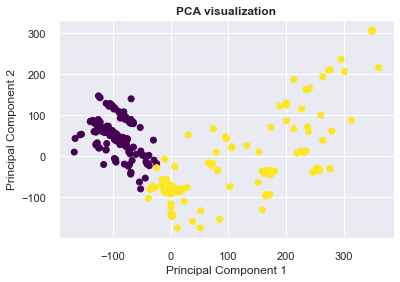

```python
clusterid, error, nfound = kcluster(X,nclusters=2)

pca = PCA(n_components=2)
X_pca = pca.fit_transform(X)

plt.scatter(X_pca[:, 0],X_pca[:, 1],c=clusterid,cmap='viridis')
plt.xlabel('Principal Component 1')
plt.ylabel('Principal Component 2')
plt.title('PCA visualization',fontweight='bold')
plt.show()
```

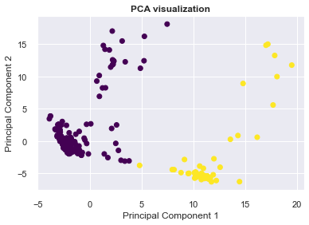

```python
clusterid, error, nfound = kcluster(X_std,nclusters=2)

pca = PCA(n_components=2)
X_pca = pca.fit_transform(X_std)

plt.scatter(X_pca[:, 0],X_pca[:, 1],c=clusterid,cmap='viridis')
plt.xlabel('Principal Component 1')
plt.ylabel('Principal Component 2')
plt.title('PCA visualization',fontweight='bold')
plt.show()
```

## Reduce dimension of data, Normalize and Clustering

```python
# length of one sequence is 34k, which is very large.
# we can use PCA to reduce the diemnsion of the data while keeping
# most of the variance.

# let's keep 90% of the variation in the data and cluster the data.
```

```python
# get numpy array
X = np.asarray([np.frombuffer(s.encode('utf-8'), dtype=np.uint8)
                     for s in sequences])
```

```python
scaler = StandardScaler()
X_std = scaler.fit_transform(X)
```

```python
from Bio.Cluster import pca
```

```python
%%time
columnmean, coordinates, components, eigenvalues = pca(X_std)

# original matrix = columnmean + np.dot(coordinates, components)
```

```
CPU times: user 19.2 s, sys: 82.6 ms, total: 19.3 s
Wall time: 19.3 s
```

```python
# normalize eigenvalues
ev_norm = eigenvalues/eigenvalues.sum()
sum(ev_norm), ev_norm[:5]
```

```
(0.9999999999999993,
 array([0.01879619, 0.0181879 , 0.01686088, 0.01615637, 0.01551226]))
```

```python
ev_norm_cumsum = ev_norm.cumsum()
ev_norm_cumsum[:5]
```

```
array([0.01879619, 0.03698408, 0.05384496, 0.07000133, 0.08551359])
```

```python
value = 0.9 # 90% variance explained
idx = (np.abs(ev_norm_cumsum - value)).argmin()
idx, ev_norm_cumsum[idx]
```

```
(258, 0.9001994506279246)
```

```python
X_std_pca = X_std[:,:idx]
X_std_pca.shape
```

```
(400, 258)
```

```python
# try other things
X_std_pca_copy = copy.deepcopy(X_std_pca)
X_std_pca = X # stdscaler gives 4 clusters good visualization, takes long time for unscaled data.

X_std_pca = X_std # 6 clusters gives good visualization for pca2 standardscaling

X_std_pca = X_std_pca_copy
```